# [CogSci] IntroStat 8 part2

### 8.1 Significance test for a population proportion

유의성 검정은 모집단에서의 비율에 대해서 할 수 있습니다. 신뢰구간을 구할 때랑 마찬가지라고 생각하시면 됩니다.

대선 후보 A 에 대한 지지율을 예로 들어보겠습니다. 지난 6개월 동안 여러 설문조사 기관에서 조사를 해 본 결과, 해당 지지율이 $p_0$ 라고 알려져 있다고 가정해 보겠습니다. 시간이 지났으니, 6개월 후인 현재에는 지지율이 어떻게 되었는 지 알고 싶습니다. 당연히 우리가 알고 싶은 것은 모집단에서의 지지율인 $p$ 입니다.

영가설을 세워보겠습니다. 영가설은 늘 주장하고 싶은 바의 반대로 설정해야 합니다. 예를 들면 신약의 효과가 **기존의 약보다 더 좋다**, 혹은 **기존의 약과는 다르다**고 주장하고 싶으면, 영가설은 **기존의 약과 별반 차이가 없다**라고 세우셔야 합니다. 지금은 $p_0$가 $p$와 다른 지 아닌 지를 알고 싶기 때문에 영가설을 두 개가 다르지 않다, 다시 말해 6개월이 지난 지금도 대선 후보 A에 대한 지지율은 변화가 없다 라고 세우겠습니다.

$H_0:P=P_0$

이에 대해 대립 가설은 여러가지가 가능하겠습니다. 지난 번 스터디에서 살펴봤던 대로 검정에는 단측 검정과 양측 검정이 있습니다.

- 단측 검정: $H_A:p$ < $p_0$, $H_A:p$ > $p_0$
- 양측 검정: $H_A:p$ $\neq$ $p_0$

지지율은 전체 응답 중 지지 응답 수로 밝혀질 테니, 지난 번 5장 설명 때 처럼 설문 조사 응답은 '지지한다'는 1번, '지지하지 않는다'는 0번으로 받았다고 하겠습니다. 그럼 '지지한다' 라는 응답의 총 갯수를 확률 변수 X(책에 the number of success 라고 쓰여있는 말이지요)라고 할 때, X는 이항 분포를 따를 것입니다. 0 혹은 1의 값을 가지는 베르누이 시행들이 여러 개 있는 경우니까요.

우리가 6개월 후에 새로이 진행한 설문조사를 통해 추출한 표본에서 구한 $\hat{p} = X/n$ 이고(n은 표본의 크기), $\hat{p}$은 n이 클 경우에 정규 분포를 따른다고 할 수 있습니다. 이 말이 이해가 안 가시는 분은 https://ohspc89.github.io/Chapter7extra1.html 의 7.2 를 다시 읽으시기 바랍니다.

$\hat{p}$을 바로 검정 통계량으로 사용할 수도 있지만, 일반적으로 이를 표준화 하여 사용합니다. 표준화에 따라 계산되는 검정 통계량은 다음과 같습니다.

$$Z = \frac{\hat{p}-E(\hat{p}|H_0)}{SD(\hat{p}|H_0)} = \frac{\hat{p}-p_0}{\sqrt{p_0(1-p_0)/n}}$$

E($\hat{p}|H_0$)는 우리가 영가설을 가정할 때 $\hat{p}$의 기대값이라는 의미입니다. E($\hat{p}$) = E($X/n$) = E($X$)/$n$ = $np/n$ = $p$ 우리의 영가설은 $H_0:P=P_0$ 였으니 결국 E($\hat{p}|H_0$) = $p_0$가 되는 것입니다. 또한 이 경우에는 $p_0$의 값을 알고 있기 때문에 신뢰구간을 구할 때와 같이 SE를 쓰지 않고 SD를 그대로 쓰셔도 됩니다.

책에 나온대로, p-value는 대립 가설이 어떤 가에 따라서 달라질 것입니다. Figure 8.3과 공식 8.1을 참고해서 설명하겠습니다.

$p_0$는 0.5 라고 가정했습니다. 표본의 크기를 n = 100 이라고 하겠습니다. 그러면 SD($\hat{p}$)는 $\sqrt{0.5^2/100}$, 곧 0.5/10 = 0.05입니다. 시각화를 위해서 각 수치에 100씩 곱해서 그림을 그리도록 하겠습니다. 표준화된 경우는 아래의 시나리오에서 한 번만 나타내겠습니다. 어차피 그게 그겁니다.

#### **P($\hat{p} \leq$ 41.78 | $H_0$) = 0.05**

이런 식으로 한쪽 방향으로만 검정하는 것을 **단측 검정, one-sided/one-tailed** 라고 합니다.

첫 번째 시나리오는 6개월이 지난 후 후보 A에 대한 지지율이 기존의 50%보다 유의미하게 작다는 대립 가설을 두고 우리가 도출한 설문 조사 결과의 유의성을 검정하는 것입니다. 우리가 관찰한 확률 변수 $\hat{p}$의 값이 41.78% 이라고 하겠습니다. 41.78은 p-value가 0.05 입니다.

p-value가 0.05 라는 의미를 잘 생각하시기 바랍니다. 그것은 41.78이라는 하나의 값을 관찰할 확률이 0.05 라는 것이 아닙니다. [-$\infty$, 41.78] 이라는 구간의 면적, 곧 그 구간 안에서 확률 변수 값을 관찰할 확률이 0.05 라는 의미입니다. 연속 확률 변수의 경우에는 점추정이 아니라 구간추정을 하는 것이라고 했습니다(https://ohspc89.github.io/chapter5part2.html)

유의 수준을 0.05 라고 설정한다면, 41.78 미만의 $\hat{p}$ 값을 관찰하는 경우 영가설($H_0: p = 50$)을 받아들일 때 해당 $\hat{p}$ 의 p-value는 0.05 미만이 되어 영가설을 기각할 수 있게 됩니다. 예를 들어, 우리가 추출한 표본에서 $\hat{p}$의 값으로 39% 라는 지지율을 확인했다면, 이는 p-value가 0.0139이고, 곧 유의 수준보다 낮기 때문에 영가설을 기각할 수 있게 되는 증거가 되는 것입니다.

반면 41.78 이상의 $\hat{p}$은 p-value가 0.05보다 크게 되어 영가설을 기각할만큼 극단적이지 않은 증거이고, 따라서 영가설을 기각할 수 없게 되는 것이지요.

이 방향의 단측 검정에서는 지지율이 50%보다 증가하지는 않았을 거라고 가정하고 있는 겁니다.

위의 통계량 Z를 고려하는 경우, $\hat{p}$이 0.39 라고 해 보겠습니다.  
그러면 계산된 Z는 $(0.39-0.5)$/$\sqrt{0.5^2/100}$ = -0.11/0.05 = -2.2 입니다.

Z는 표준정규분포를 따르는 확률 변수이기 때문에, 단측 검정에서 P(Z $\leq$ -2.2)는 R 코드 **pnorm(-2.2, 0, 1)**으로 구할 수 있습니다. 이 결과 값은 역시 0.0139가 나오는 것을 확인할 수 있습니다. 이런 식으로 $\hat{p}$를 표준화하여 유의성 검정을 할 수 있습니다.

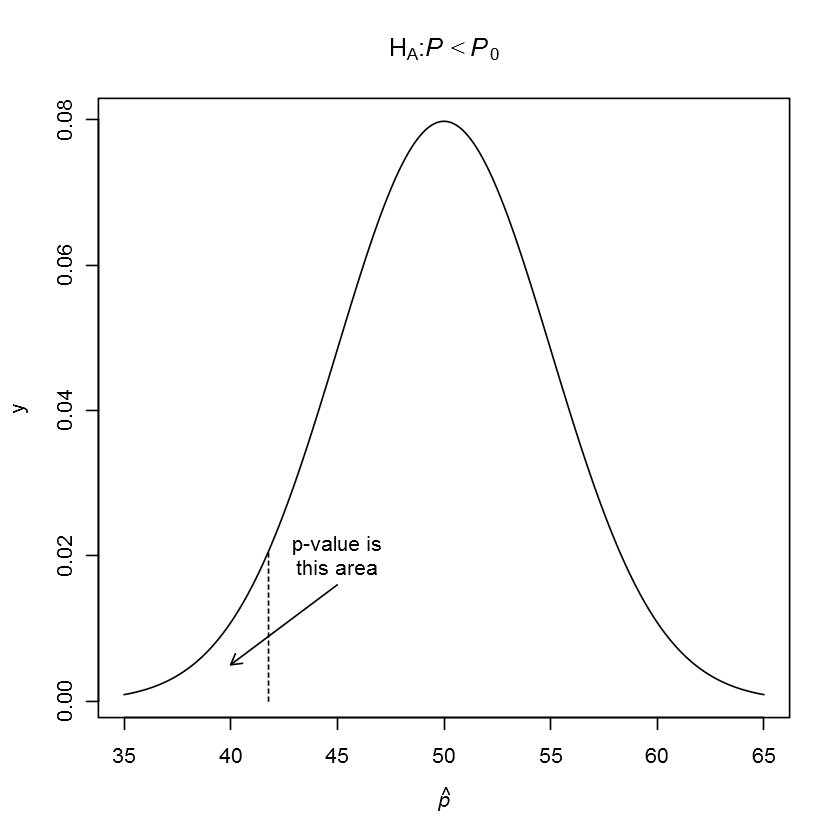

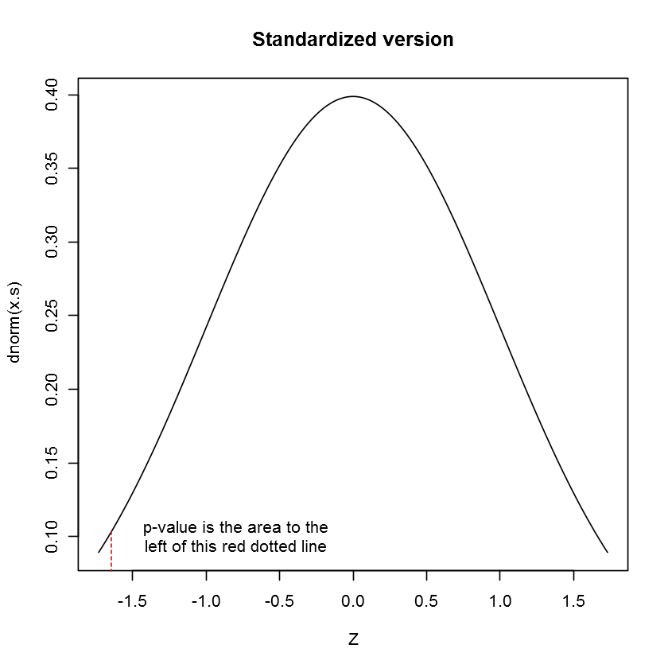

```r
x <- seq(35, 65, 0.01)
x.s <- scale(x)
y <- dnorm(x, 50, 5)
plot(x, y, type="l", main = expression(paste(H[A],":", italic(P), ""<"", italic(P[0]))),
    xlab=expression(italic(hat(p))))
# z1 is the corresponding z that makes P(X<=z) = 0.05
z1 <- qnorm(0.05, 50, 5)
lines(c(z1,z1),c(0,dnorm(z1,50,5)), lty=2)
text(45, 0.02, "p-value is\nthis area")
arrows(45, 0.016, 40, 0.005, length=0.1, code=2)

# standardized version
plot(x.s, dnorm(x.s), type="l", main="Standardized version", xlab="Z")
z1.s <- qnorm(0.05, 0, 1)
lines(c(z1.s, z1.s), c(0, dnorm(z1.s, 0, 1)), lty=2, col=2)
text(-0.8, 0.1, "p-value is the area to the\nleft of this red dotted line")
```

```r
# p-value of the observed value = 27.33; reject the null hypothesis
options(digits=3)
print(pnorm(39, 50, 5))
```

```
[1] 0.0139
```

```r
pnorm(-2.2, 0, 1)
```

0.0139034475134986

#### **P($\hat{p} \geq$ 58.22 | $H_0$) = 0.05**

두 번째 시나리오는 6개월이 지난 후 후보 A에 대한 지지율이 기존의 50%보다 유의미하게 크다는 대립 가설을 두고 우리가 도출한 설문 조사 결과의 유의성을 검정하는 것입니다. 이번엔 우리가 관찰한 확률 변수 $\hat{p}$의 값이 58.22% 이라고 하겠습니다. 58.22 역시 p-value가 0.05 입니다.

첫 번째 시나리오와 다른 점은 방향 뿐입니다. 나머지는 다 같은 이야기입니다. 마찬가지로 이렇게 검정할 경우, 지지율이 50%보다 떨어지지는 않았을 거라고 가정하고 있는 셈입니다.

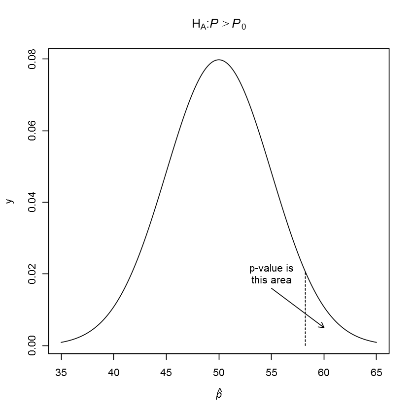

```r
x <- seq(35, 65, 0.01)
y <- dnorm(x, 50, 5)
plot(x, y, type="l", main = expression(paste(H[A],":", italic(P), "">"", italic(P[0]))),
    xlab=expression(italic(hat(p))))
z2 <- qnorm(0.95, 50,5)
lines(c(z2,z2),c(0,dnorm(z2,50,5)), lty=2)
text(55, 0.02, "p-value is\nthis area")
arrows(55, 0.016, 60, 0.005, length=0.1)
```

#### **P(|$\hat{p} - p_0$| $\geq$ |$\pm$9.8| | $H_0$) = 0.05**

세 번째 시나리오는 6개월 후의 지지도는 이전의 지지도라고 알려진 50%와는 분명히 다를 건데, 더 큰 값일지 작은 값일지는 알 수 없다고 가정하는 경우의 유의성 검정입니다. 이런 경우를 **양측 검정, two-sided/two-tailed** 라고 표현합니다.

|$\pm$9.8|이라는 값은 책의 8.1 공식에 쓰여있는 대로 |observed value - $p_0$| 입니다. 관찰한 값이 40.2% 혹은 59.8% 라고 가정한 겁니다. |40.2 - 50| = |-9.8| = 9.8 이고, |59.8 - 50| = |9.8| = 9.8 이기 때문입니다.

이제 이 경우에는 아래의 pdf 에서도 확인할 수 있듯이, p-value의 영역이 둘로 쪼개집니다. 그래서 이 두 영역의 합이 곧 p-value가 됩니다. 당연히 각 기각역의 면적은 단측 검정에서 살펴본 기각역 면적의 절반이 될 겁니다. 관찰된 $\hat{p}$의 값이 40.2% 미만 혹은 59.8% 초과일 경우, 영가설을 기각할 수 있게 됩니다.

생각해 보면, 이 시나리오에서 표준화를 해서 Z 라는 확률 변수의 pdf 를 그려보면, critical values가 -1.96, 1.96 일겁니다.

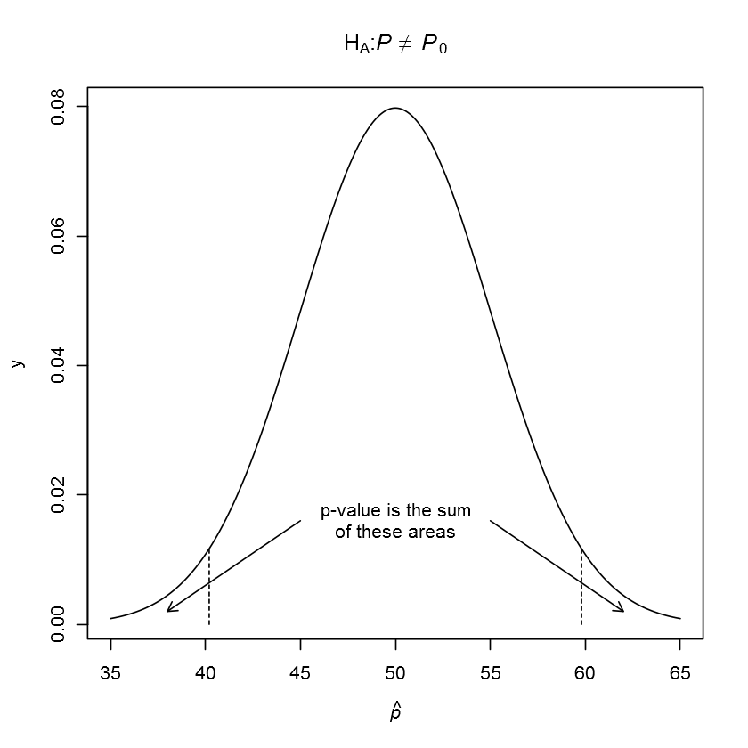

```r
x <- seq(35, 65, 0.01)
y <- dnorm(x, 50, 5)
plot(x, y, type="l", main = expression(paste(H[A],":", italic(P), ""!="", italic(P[0]))),
    xlab=expression(italic(hat(p))))
z3 <- qnorm(0.025, 50, 5)
z4 <- qnorm(0.975, 50, 5)
lines(c(z3,z3),c(0,dnorm(z3,50,5)), lty=2)
lines(c(z4,z4),c(0,dnorm(z4,50,5)), lty=2)
arrows(38, 0.002, 45, 0.016, length=0.1, code=1)
arrows(62, 0.002, 55, 0.016, length=0.1, code=1)
text(50, 0.016, "p-value is the sum\nof these areas")
```